# Lab 3

Kent Codding

2023-09-14

# Set up

```r
setwd("C:/Users/Kent Codding/Desktop/Adv Biostat")
covid_df <- read.csv("Lab 2/all_data.csv")
vote_df <- read.csv("Lab 3/vote.csv")
```

# clean data if necessary

```r
str(vote_df)
```

```
## 'data.frame':    50 obs. of  13 variables:
##  $ state           : chr  "Alabama" "Alaska" "Arizona" "Arkansas" ...
##  $ called          : chr  "R" "R" "D" "R" ...
##  $ dem_votes       : int  849624 153778 1672143 423932 11110250 1804352 1080831 296268 5297045 2473633 ...
##  $ rep_votes       : int  1441170 189951 1661686 760647 6006429 1364607 714717 200603 5668731 2461854 ...
##  $ other_votes     : int  32488 15801 53497 34490 384192 87993 28309 7475 101680 62229 ...
##  $ dem_percent     : num  36.6 42.8 49.4 34.8 63.5 55.4 59.3 58.7 47.9 49.5 ...
##  $ rep_percent     : num  62 52.8 49.1 62.4 34.3 41.9 39.2 39.8 51.2 49.3 ...
##  $ other_percent   : num  1.4 4.4 1.6 2.8 2.2 2.7 1.6 1.5 0.9 1.2 ...
##  $ dem_this_margin : num  -25.5 -10.1 0.3 -27.6 29.2 13.5 20.1 19 -3.4 0.2 ...
##  $ margin_shift    : num  2.3 4.7 3.9 -0.7 -0.9 8.6 6.4 7.6 -2.2 5.4 ...
##  $ vote_change     : num  9.4 12.8 31.6 7.8 23.4 17.1 10.9 14.2 17.5 22.1 ...
##  $ stateid         : chr  "AL" "AK" "AZ" "AR" ...
##  $ Total.2016.Votes: num  2123372 318608 2573165 1130635 14181595 ...
```

```r
str(covid_df)
```

```
## 'data.frame':    50 obs. of  31 variables:
##  $ X                      : int  1 2 3 4 5 6 7 8 9 10 ...
##  $ Row.names              : chr  "Alabama" "Alaska" "Arizona" "Arkansas" ...
##  $ perc_one_dose          : num  65.1 73.2 78.4 70.1 85.1 84 95 88.5 82.9 68.6 ...
##  $ perc_fully_vax         : num  53.3 65.3 66.2 57 74.9 73.8 83.2 73.5 69.7 57.5 ...
##  $ total_deaths           : int  22342 1514 29685 12531 108732 14953 12284 3453 79794 36119 ...
##  $ death_rate_3_months    : num  2 NA 1.8 1.9 1.7 1.6 1 1.6 2.8 1.8 ...
##  $ total_death_rate       : num  359 227 324 338 245 ...
##  $ new_case_rate_this_week: num  7.63 2.87 3.48 6.86 6.56 3.32 5.16 3.7 11.2 7.27 ...
##  $ abbr                   : chr  "AL" "AK" "AZ" "AR" ...
##  $ fips                   : int  1 2 4 5 6 8 9 10 12 13 ...
##  $ pop2010                : int  4779736 710231 6392017 2915918 37253956 5029196 3574097 897934 18801310 9687653 ...
##  $ pop2000                : int  4447100 626932 5130632 2673400 33871648 4301261 3405565 783600 15982378 8186453 ...
##  $ homeownership          : num  71.1 64.7 67.4 67.7 57.4 67.6 69.2 73.6 69.7 67.2 ...
##  $ multiunit              : num  15.5 24.6 20.7 15.2 30.7 25.6 34.6 17.7 30 20.5 ...
```

[output cut: 17 more lines]

```r
library(magrittr) # for pipe operator
any(vote_df %>% is.na() == T) # checks if any NA values exist => none exist within DF
```

```
## [1] FALSE
```

```r
any(covid_df %>% is.na() == T) # some exist within COVID DF
```

```
## [1] TRUE
```

```r
indices = which(covid_df %>% is.na() == T)
covid_df[indices,] #can see all indices are indeed NA
```

[output not shown]

[output cut: 55 more lines]

[output not shown]

# Load packages

```r
library(ggplot2)
library(usmap)
```

## check if rownames match up in both dfs

```r
rownames(vote_df) == rownames(covid_df)
```

```
##  [1] TRUE TRUE TRUE TRUE TRUE TRUE TRUE TRUE TRUE TRUE TRUE TRUE TRUE TRUE TRUE
## [16] TRUE TRUE TRUE TRUE TRUE TRUE TRUE TRUE TRUE TRUE TRUE TRUE TRUE TRUE TRUE
## [31] TRUE TRUE TRUE TRUE TRUE TRUE TRUE TRUE TRUE TRUE TRUE TRUE TRUE TRUE TRUE
## [46] TRUE TRUE TRUE TRUE TRUE
```

# Examine response variables

**Question 1:** Analyzing case rates reduces bias between states with high population and low population. For example, the most populated state, California, will almost undoubtedly have more cases than Wyoming, the least populated state. A better metric to compare would be the case rate: Covid deaths per 100,000 people. This metric tells us whether a person is more likely to die in California or Wyoming.

## Graph it

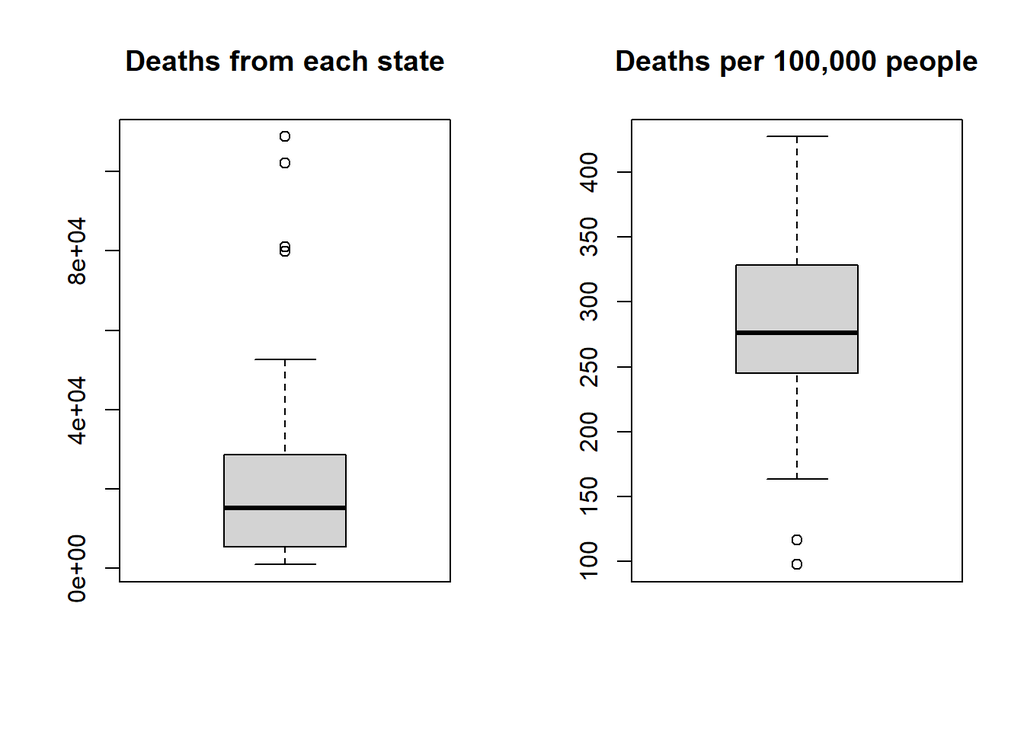

```r
par(mfrow = c(1,2)) #mfrow set up like matrix c(numrows, numcols) to create side by side charts
boxplot(covid_df$total_deaths,
        main = "Deaths from each state"
        )
boxplot(covid_df$total_death_rate,
        main = "Deaths per 100,000 people"
        )
```

## Graph it to pdf

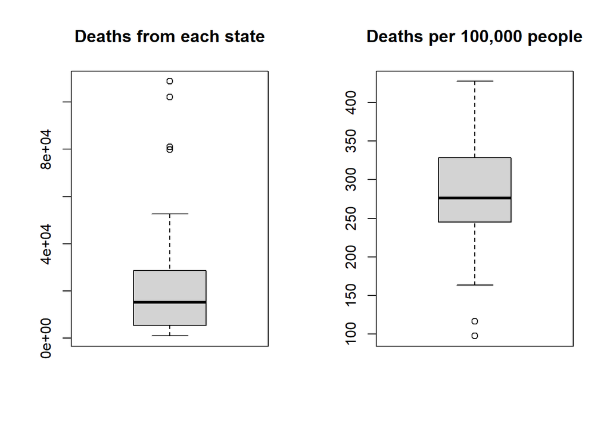

```r
par(mfrow = c(1,2)) #mfrow set up like matrix c(numrows, numcols) to create side by side charts
boxplot(covid_df$total_deaths,
        main = "Deaths from each state"
        )
boxplot(covid_df$total_death_rate,
        main = "Deaths per 100,000 people"
        )
```

```r
#pdf(file = "Lab 3/Covid death rate by state.pdf", width = 8, height = 6)
#Note: I commented this out after running this code chunk once to save to pdf.
```

**Question 2:**

```r
#Find the outliers!!
summary(covid_df$total_deaths)
```

```
##    Min. 1st Qu.  Median    Mean 3rd Qu.    Max.
##    1016    5580   15266   22752   27954  108732
```

```r
#get IQR
IQR(covid_df$total_deaths)
```

```
## [1] 22374.5
```

```r
# get threshold values for outliers
Tmin = 5580-(1.5*22374.5) #first quartile minus 1.5*IQR
Tmax = 27954+(1.5*22374.5) ##third quartile plus 1.5*IQR

subset(covid_df, total_deaths > Tmax)[,2]
```

```
## [1] "California" "Florida"    "New York"   "Texas"
```

```r
#the output shows states with total deaths greater than the Tmax threshold calculated above. These states are also the four most populated in the country, which explains why the total is higher than the less populated states.
```

# Histograms and data distributions

## Graph it

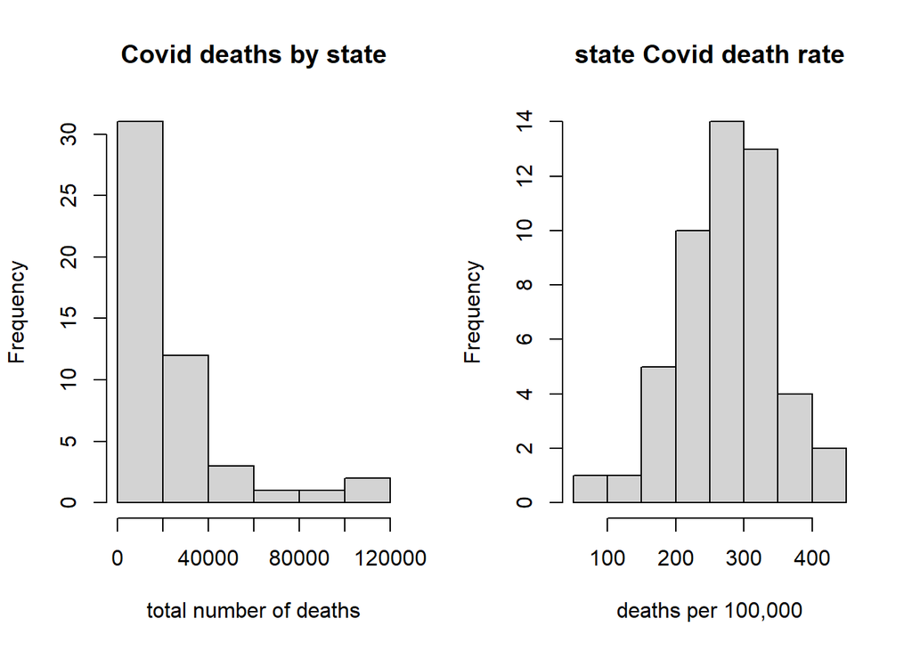

```r
par(mfrow = c(1,2)) #mfrow set up like matrix c(numrows, numcols) to create side by side charts

hist(covid_df$total_deaths,
     xlab = "total number of deaths",
     main = "Covid deaths by state")
hist(covid_df$total_death_rate,
     xlab = "deaths per 100,000",
     main = "state Covid death rate")
```

**Question 3:** The total number of deaths does not show a normal distribution bell curve. This is because total number of deaths for each state correlates with the total population of each state, which does not show a normal distribution as some states are much more populated than others like California and Texas.

# Map plotting

## Spatial correlation

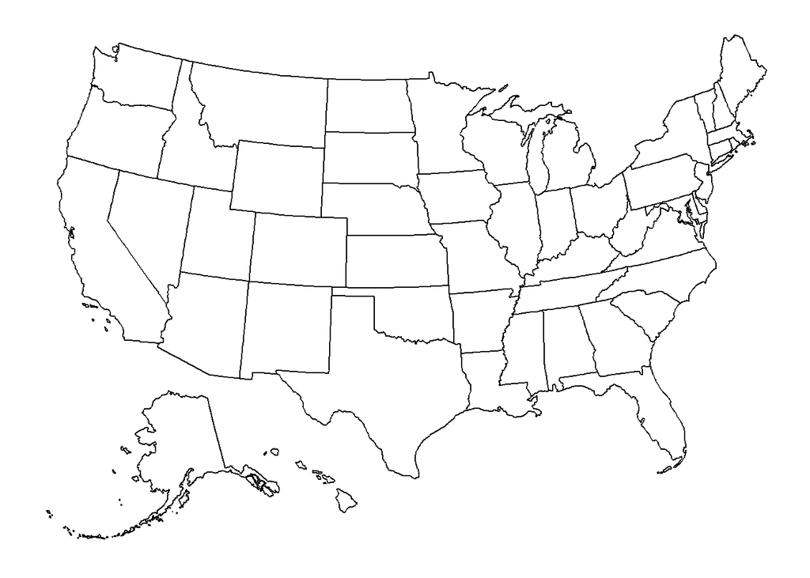

```r
plot_usmap()
```

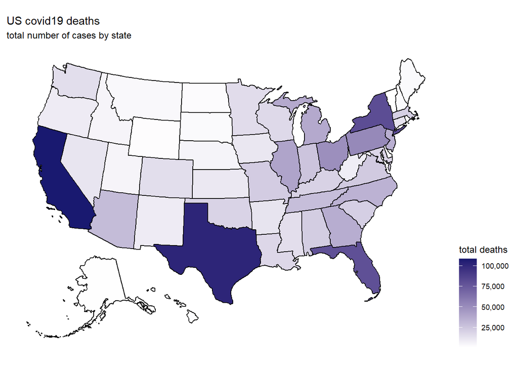

```r
#first we have to add a column to our covid_df called "state".
#the plot_usmap() function requires this column to work
covid_df$state <- rownames(covid_df)

plot_usmap(data = covid_df, values = "total_deaths") +
  scale_fill_continuous(low = "white", high = "midnightblue",
          label = scales::comma, name = "total deaths") +
          theme(legend.position = "right") +
          labs(title = "US covid19 deaths",
               subtitle = "total number of cases by state")
```

## Graph it

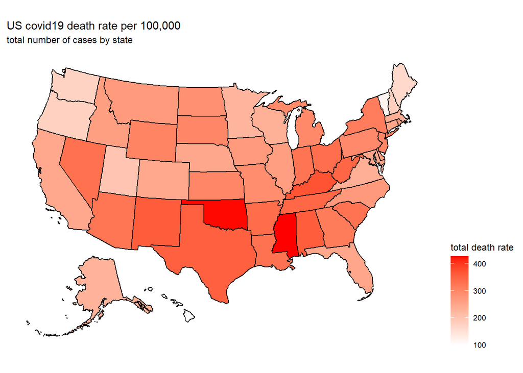

```r
plot_usmap(data = covid_df, values = "total_death_rate") +
  scale_fill_continuous(low = "white", high = "red",
          label = scales::comma, name = "total death rate") +
          theme(legend.position = "right") +
          labs(title = "US covid19 death rate per 100,000",
               subtitle = "total number of cases by state")
```

**Question 4:** The case rate map eliminates the confounding variable of total state population. This map shows the states where people are most likely to die from COVID.

# Strip charts for correlations between numeric and categorical variables

## Graph it

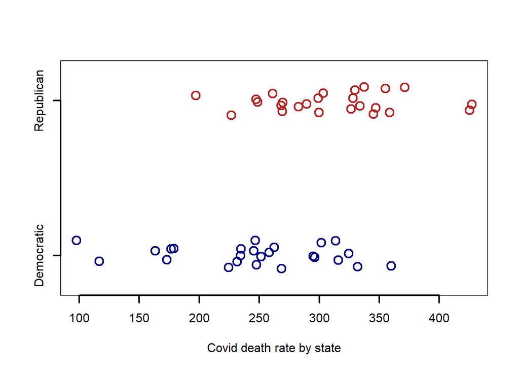

```r
stripchart(covid_df$total_death_rate ~ vote_df$called,
           col = c("navyblue", "firebrick"), # choose colors
           method = "jitter", #adds minor variation
                              #in data to limit overlapping of points
           pch = 1, # controls the shape of the data points
           xlab = "Covid death rate by state",
           group.names = c("Democratic","Republican"),
           cex = 1.5, lwd = 2 #controls size and line thickness of points
           )
```

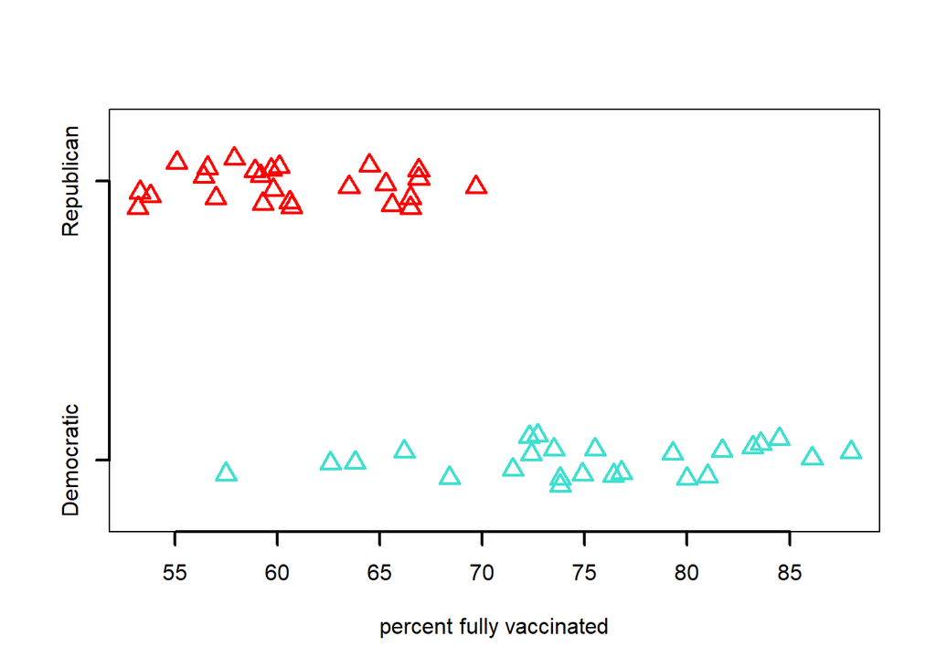

```r
stripchart(covid_df$perc_fully_vax ~ vote_df$called,
           col = c("turquoise", "red"), # choose colors
           method = "jitter", #adds minor variation
                              #in data to limit overlapping of points
           pch = 2, # controls the shape of the data points
           xlab = "percent fully vaccinated",
           group.names = c("Democratic","Republican"),
           cex = 1.5, lwd = 2 #controls size and line thickness of points
           )
```

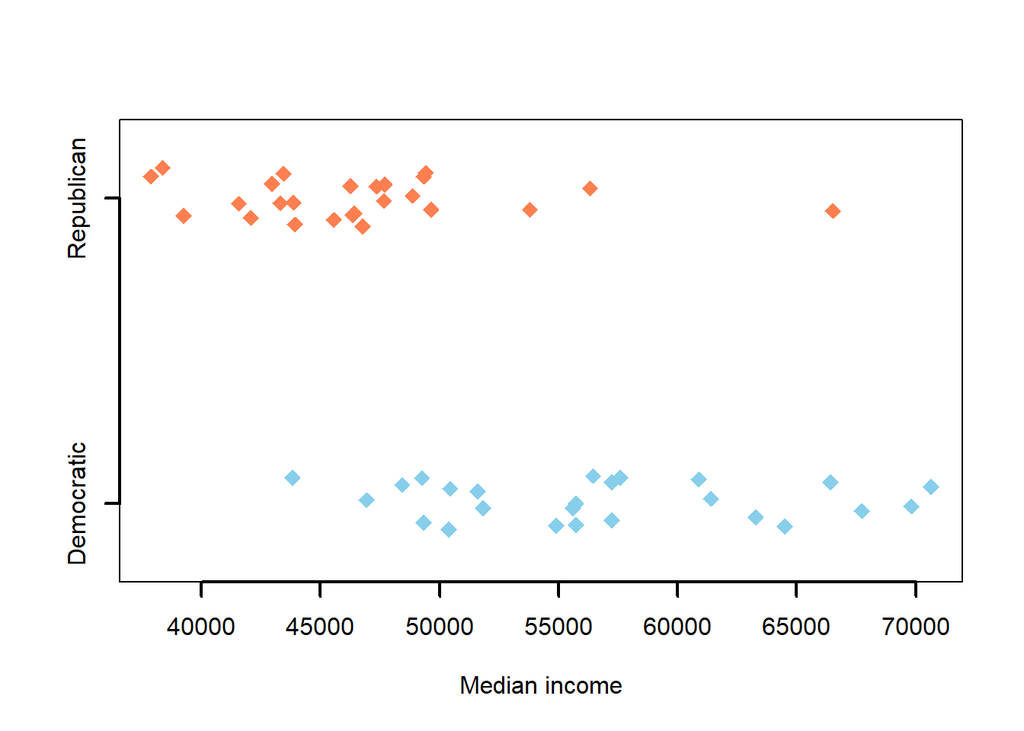

```r
stripchart(covid_df$med_income ~ vote_df$called,
           col = c("skyblue", "coral"), # choose colors
           method = "jitter", #adds minor variation
                              #in data to limit overlapping of points
           pch = 18, # controls the shape of the data points
           xlab = "Median income",
           group.names = c("Democratic","Republican"),
           cex = 1.5, lwd = 2 #controls size and line thickness of points
           )
```

**Question 5:** Yes, states that voted Democrat generally had a lower death rate. Additionally, states that voted Republican generally had a lower vaccination rate. Hence, vaccination rate and other variables like regulations and mask wearing likely affected the overall death rate per state. Evidently, political party affiliation explains businesses and individual decisions behind vaccination and masking up…

# Scatter plots of correlations between numerical variables

## Graph it

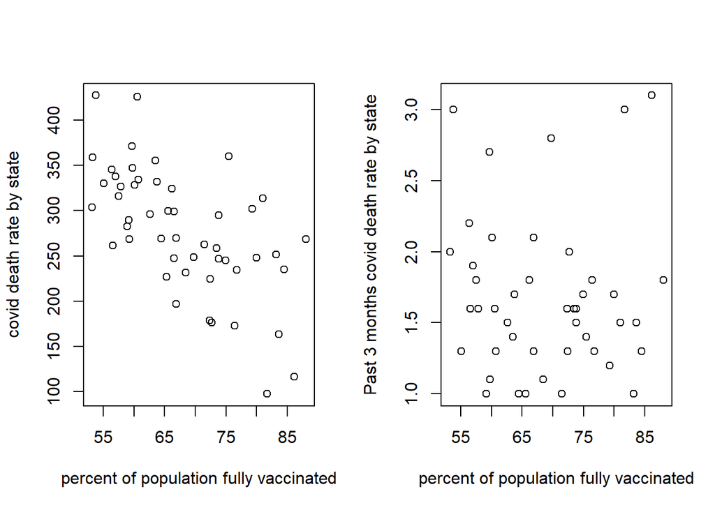

```r
par(mfrow = c(1,2)) #mfrow set up like matrix c(numrows, numcols) to create side by side charts
plot(total_death_rate ~ perc_fully_vax, data = covid_df, xlab = "percent of population fully vaccinated", ylab = "covid death rate by state")
plot(death_rate_3_months ~ perc_fully_vax, data = covid_df, xlab = "percent of population fully vaccinated", ylab = "Past 3 months covid death rate by state")
```

# Fancy up that plot

## Graph it

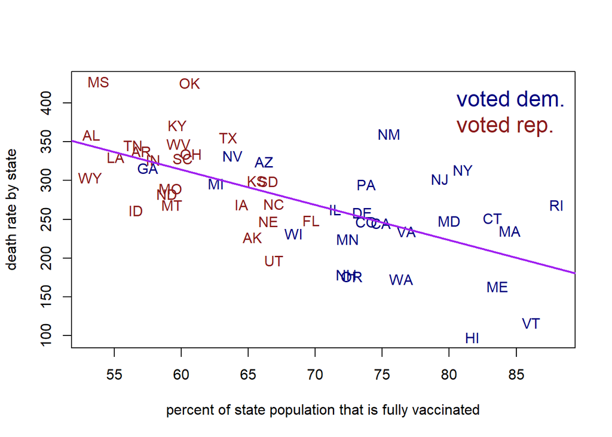

```r
#make a custom color pallet called "clr"
clr <- c("navy", "firebrick4")

#set up the plotting space
plot(total_death_rate ~ perc_fully_vax, data = covid_df,
     type = "n",
     xlab = "percent of state population that is fully vaccinated",
     ylab = "death rate by state"
     )

# The argument type = "n" tells R to make a blank plotting space
# now we can use the "text" function to plot our data using the
# state name abbreviations, which are in the vote_df dataframe under "stateid"
# first we'll only plot the states that voted democratic by subsetting
# and we'll make them blue (i.e. the first color in our pallet "clr")

text(total_death_rate ~ perc_fully_vax, #gives the coordinates to plot the stat abbr.
     lab = vote_df$stateid[vote_df$called == "D"], #tells which text to plot
     data = subset(covid_df, vote_df$called == "D"), #subsets only the D states
     col = clr[1]) #color of the text

#now we'll plot the states that voted republican
#and make them red

text(total_death_rate ~ perc_fully_vax,
     lab = vote_df$stateid[vote_df$called == "R"],
     data = subset(covid_df, vote_df$called == "R"),
     col = clr[2])

#Add a legend
legend("topright",    #puts legend in the top right corner
       legend = c("voted dem.","voted rep."), #list of things in legend
       text.col = clr, #colors to use for the text
       bty = 'n', #this tells R to not draw a box around the legend
       cex = 1.5) # this increases the font size by 50%

#Add a trend line using abline
#this is a function for adding lines to plots
#we can use a simple linear model (lm()) to define our line
#we'll talk much more about lm() next time,
#so don't worry if it is new to you now
abline(
  lm(total_death_rate ~ perc_fully_vax, data = covid_df),
  lwd = 2, col = "purple") #set line width and color
```